# B-Spline Mixed Effects Linear Regression Simulation Study

Laurens Bogaardt

2024-04-01

# Introduction

This document describes a simulation study of a mixed effects linear regression model with a 3-part B-spline as a fixed effect and a single random intercept per participant. First, the model is used to generate multiple datasets which are subsequently analysed to estimate the model’s parameters via maximum likelihood. Various estimation methods are used and compared. All methods result in the same estimates but some are computationally faster than others. The document uses the packages *tidyverse*, *JOPS*, *nlme*, *lme4*, *gamlss*, *mgcv* and *matrixStats*. And we set a seed to ensure each run of this document produces the same output.

```r
library(tidyverse)
library(JOPS)
library(nlme)
library(lme4)
library(gamlss)
library(mgcv)
library(matrixStats)
set.seed(123)
```

# Functions

The following function generates data for a mixed effects linear regression model. The subsequent functions estimate the parameters which best fit these data assuming the same model. This is done using multiple estimation methods which all result in the same maximum likelihood estimates.

```r
generate.data <- function(n.participants, n.measurements, logit.ratio.1, logit.ratio.2, logit.ratio.3) {
  participant.id <- factor(rep(seq(n.participants), each = n.measurements))
  x <- rep(runif(n.participants), each = n.measurements)
  x.matrix <- bbase(x, xl = 0, xr = 1, nseg = 1, bdeg = 2)
  logit.ratio <- c(x.matrix %*% c(logit.ratio.1, logit.ratio.2, logit.ratio.3))
  sd.random.intercept <- exp(logit.ratio) / (1 + exp(logit.ratio))
  sd.error <- 1 / (1 + exp(logit.ratio))
  random.intercept <- sd.random.intercept * rep(rnorm(n.participants), each = n.measurements)
  error <- sd.error * rnorm(n.participants * n.measurements)
  y <- random.intercept + error
  data <- data.frame(
    n.participants = n.participants,
    n.measurements = n.measurements,
    logit.ratio.1 = logit.ratio.1,
    logit.ratio.2 = logit.ratio.2,
    logit.ratio.3 = logit.ratio.3,
    participant.id = participant.id,
    x = x,
    y = y
  )
  return(data)
}
```

The following estimation method makes use of the *gamlss* function of the package *gamlss* and uses the *re* function to specify the random part of the model.

```r
estimate.model.and.get.coefficients.gamlss1 <- function(data) {
  data.gamlss1 <<- data
  ptm <- proc.time()
  model <- gamlss(
    formula = y ~ 0 + re(fixed = ~ 0 + bbase(x, xl = 0, xr = 1, nseg = 1, bdeg = 2), random = ~ 0 + bbase(x, xl = 0, xr = 1, nseg = 1, bdeg = 2) | participant.id),
    sigma.formula = ~ 0 + bbase(x, xl = 0, xr = 1, nseg = 1, bdeg = 2),
    family = NO(
      mu.link = "log",
      sigma.link = "log"
    ),
    data = data.gamlss1,
    trace = FALSE
  )
  time <- proc.time() - ptm
  result <- c(
    fixed.coefficient.1 = fixef(getSmo(model))[[1]],
    fixed.coefficient.2 = fixef(getSmo(model))[[2]],
    fixed.coefficient.3 = fixef(getSmo(model))[[3]],
    sd.random.intercept = as.numeric(VarCorr(getSmo(model))[[3]]),
    sd.error = as.numeric(VarCorr(getSmo(model))[[4]]) * exp(model[["sigma.coefficients"]][["(Intercept)"]]),
    time = time[[3]]
  )
  return(result)
}
```

The following estimation method makes use of the *gamlss* function of the package *gamlss* and uses the *random* function to specify the random part of the model.

```r
estimate.model.and.get.coefficients.gamlss2 <- function(data) {
  data.gamlss2 <<- data
  ptm <- proc.time()
  model <- gamlss(
    formula = y ~ 0 + bbase(x, xl = 0, xr = 1, nseg = 1, bdeg = 3) + random(participant.id),
    sigma.formula = ~ 1,
    family = NO(
      mu.link = "identity",
      sigma.link = "log"
    ),
    data = data.gamlss2,
    trace = FALSE
  )
  time <- proc.time() - ptm
  result <- c(
    fixed.coefficient.1 = model$mu.coefficients[[1]],
    fixed.coefficient.2 = model$mu.coefficients[[2]],
    fixed.coefficient.3 = model$mu.coefficients[[3]],
    fixed.coefficient.4 = model$mu.coefficients[[4]],
    sd.random.intercept = getSmo(model, "mu")[["sigb"]],
    sd.error = getSmo(model, "mu")[["sige"]] * exp(model$sigma.coefficients),
    time = time[[3]]
  )
  return(result)
}
```

The following estimation method makes use of the *gam* function of the package *mgcv*.

```r
estimate.model.and.get.coefficients.mgcv1 <- function(data) {
  ptm <- proc.time()
  model <- gam(
    formula = y ~ 0 + bbase(x, xl = 0, xr = 1, nseg = 1, bdeg = 3) + s(participant.id, bs = "re"),
    data = data,
    method = "ML"
  )
  time <- proc.time() - ptm
  invisible(
    capture.output(
      result <- c(
        fixed.coefficient.1 = coef(model)[[1]],
        fixed.coefficient.2 = coef(model)[[2]],
        fixed.coefficient.3 = coef(model)[[3]],
        fixed.coefficient.4 = coef(model)[[4]],
        sd.random.intercept = gam.vcomp(model)[[1]],
        sd.error = gam.vcomp(model)[[2]],
        time = time[[3]]
      )
    )
  )
  return(result)
}
```

The following estimation method makes use of the *gamm* function of the package *mgcv*.

```r
estimate.model.and.get.coefficients.mgcv2 <- function(data) {
  ptm <- proc.time()
  model <- gamm(
    formula = y ~ 0 + bbase(x, xl = 0, xr = 1, nseg = 1, bdeg = 3),
    random = list(participant.id = ~ 1),
    data = data,
    method = "ML"
  )
  time <- proc.time() - ptm
  result <- c(
    fixed.coefficient.1 = fixef(model$lme)[[1]],
    fixed.coefficient.2 = fixef(model$lme)[[2]],
    fixed.coefficient.3 = fixef(model$lme)[[3]],
    fixed.coefficient.4 = fixef(model$lme)[[4]],
    sd.random.intercept = as.numeric(VarCorr(model[["lme"]])[[3]]),
    sd.error = model$lme[["sigma"]],
    time = time[[3]]
  )
  return(result)
}
```

The following estimation method uses a custom likelihood function which is optimised using the function *optim* and which also makes use of the function *logSumExp* from the package *matrixStats*.

```r
estimate.model.and.get.coefficients.optim <- function(data) {
  fixed.coefficient.1 <- data$fixed.coefficient.1[[1]]
  fixed.coefficient.2 <- data$fixed.coefficient.2[[1]]
  fixed.coefficient.3 <- data$fixed.coefficient.3[[1]]
  fixed.coefficient.4 <- data$fixed.coefficient.4[[1]]
  sd.random.intercept <- data$sd.random.intercept[[1]]
  sd.error <- data$sd.error[[1]]
  participant.id <- data$participant.id
  fun.ri <- function(i, y, fixed.effect, log.sd.random.intercept, log.sd.error) {
    -sum(((fixed.effect + exp(log.sd.random.intercept) * i - y) / exp(log.sd.error)) ^ 2 / 2 + log.sd.error) - i ^ 2 / 2
  }
  ri <- seq(-4, 4, 0.05)
  fun.split <- function(split.data, par) {
    x <- split.data$x
    y <- split.data$y
    x.matrix <- bbase(x, xl = 0, xr = 1, nseg = 1, bdeg = 3)
    fixed.effect <- c(x.matrix %*% par[seq(4)])
    log.sd.random.intercept <- par[[5]]
    log.sd.error <- par[[6]]
    logSumExp(sapply(ri, fun.ri, y, fixed.effect, log.sd.random.intercept, log.sd.error))
  }
  data.split <- split(data[c("x", "y")], participant.id)
  fun.optim <- function(par) {
    -sum(sapply(data.split, fun.split, par))
  }
  ptm <- proc.time()
  model <- optim(
    par = c(fixed.coefficient.1, fixed.coefficient.2, fixed.coefficient.3, fixed.coefficient.4, log(sd.random.intercept), log(sd.error)),
    fn = fun.optim,
    method = "BFGS"
  )
  time <- proc.time() - ptm
  result <- c(
    fixed.coefficient.1 = model$par[[1]],
    fixed.coefficient.2 = model$par[[2]],
    fixed.coefficient.3 = model$par[[3]],
    fixed.coefficient.4 = model$par[[4]],
    sd.random.intercept = exp(model$par[[5]]),
    sd.error = exp(model$par[[6]]),
    time = time[[3]]
  )
  return(result)
}
```

```r
estimate.model.and.get.coefficients.gls <- function(data) {
  n.participants <- data$n.participants[[1]]
  n.measurements <- data$n.measurements[[1]]
  logit.ratio.1 <- data$logit.ratio.1[[1]]
  logit.ratio.2 <- data$logit.ratio.2[[1]]
  logit.ratio.3 <- data$logit.ratio.3[[1]]
  x <- data$x
  y <- data$y
  x.matrix <- bbase(x, xl = 0, xr = 1, nseg = 1, bdeg = 2)
  x.2 <- x[seq(1, n.participants * n.measurements, n.measurements)]
  id.2 <- data$participant.id[seq(1, n.participants * n.measurements, n.measurements)]
  x.matrix.2 <- bbase(x.2, xl = 0, xr = 1, nseg = 1, bdeg = 2)
  make.matrix <- function(v1, v2, n) {
    diag(v1, n) + matrix(v2, n, n)
  }
  y.split <- split(data$y, data$participant.id)
  x.split <- split(x.matrix.2, id.2)
  measur <- lapply(y.split, length)
  ff <- function(x, y, measur, par) {
    logit.ratio <- sum(x * par)
    sd.random.intercept <- exp(logit.ratio) / (1 + exp(logit.ratio))
    sd.error <- 1 / (1 + exp(logit.ratio))
    covariance.matrix <- make.matrix(sd.error ^ 2, sd.random.intercept ^ 2, measur)
    chol.matrix <- chol(covariance.matrix)
    z <- forwardsolve(t(chol.matrix), y)
    log.sqrt.det <- sum(log(diag(chol.matrix)))
    loglikelihood <- - z %*% z / 2 - log.sqrt.det - log(2 * pi) * (measur / 2)
    return(loglikelihood)
  }
  fun.gls <- function(par) {
    loglikelihood <- sum(mapply(
      ff,
      x.split,
      y.split,
      measur,
      MoreArgs = list(par = par)
    ))
    return(loglikelihood)
  }
  ptm <- proc.time()
  optimise.correlation.gls <- optim(
    par = c(logit.ratio.1, logit.ratio.2, logit.ratio.3),
    fn = fun.gls,
    control = list(fnscale = -1)
  )
  time <- proc.time() - ptm
  par <- optimise.correlation.gls$par
  result <- c(
    logit.ratio.1 = par[[1]],
    logit.ratio.2 = par[[2]],
    logit.ratio.3 = par[[3]],
    time = time[[3]]
  )
  return(result)
}
```

The following function combines all previous estimation functions to be able to estimate and compare model parameters on the same input dataset.

```r
estimate.all.models.and.get.coefficients <- function(data) {
  result <- data.frame(
    method = c("gls"),
    rbind(
      estimate.model.and.get.coefficients.gls(data)
    )
  )
  return(result)
}
```

# Parameters

The mixed effects linear regression takes various input parameters. These can all be varied, one by one, which results in a table of input parameters on which the simulation study is performed.

```r
parameters <- tibble(
  parameter.set = seq(4),
  n.participants = c(200, 800, 200, 200),
  n.measurements = c(4, 4, 16, 4),
  logit.ratio.1 = c(-3, -3, -3, 0),
  logit.ratio.2 = c(2, 2, 2, 1),
  logit.ratio.3 = c(-1, -1, -1, 1)
)
parameters
```

| parameter.set | n.participants | n.measurements | logit.ratio.1 | logit.ratio.2 | logit.ratio.3 |
| --- | --- | --- | --- | --- | --- |
| 1 | 200 | 4 | -3 | 2 | -1 |
| 2 | 800 | 4 | -3 | 2 | -1 |
| 3 | 200 | 16 | -3 | 2 | -1 |
| 4 | 200 | 4 | 0 | 1 | 1 |

# Estimation

```r
estimated.parameters <- parameters %>%
  expand_grid(
    run = seq(4)
  ) %>%
  reframe(
    generate.data(
      n.participants = n.participants,
      n.measurements = n.measurements,
      logit.ratio.1 = logit.ratio.1,
      logit.ratio.2 = logit.ratio.2,
      logit.ratio.3 = logit.ratio.3
    ) %>%
      estimate.all.models.and.get.coefficients(),
    .by = c(parameter.set, run)
  )
estimated.parameters
```

| parameter.set | run | method | logit.ratio.1 | logit.ratio.2 | logit.ratio.3 | time |
| --- | --- | --- | --- | --- | --- | --- |
| 1 | 1 | gls | -3.19103434 | 1.8695760 | -0.63471731 | 1.64 |
| 1 | 2 | gls | -3.50430190 | 2.1840616 | -1.28843616 | 0.92 |
| 1 | 3 | gls | -2.40666256 | 1.6241724 | -0.01995162 | 1.84 |
| 1 | 4 | gls | -1.69830934 | 1.5552265 | -0.09199447 | 1.67 |
| 2 | 1 | gls | -3.09922460 | 2.0498296 | -1.09440581 | 3.43 |
| 2 | 2 | gls | -3.30278504 | 2.0994572 | -1.16567798 | 4.80 |
| 2 | 3 | gls | -2.95768361 | 1.9974195 | -0.97175719 | 3.15 |
| 2 | 4 | gls | -2.84684981 | 1.9216016 | -0.92176900 | 4.63 |
| 3 | 1 | gls | -2.87495102 | 1.9383709 | -0.88545553 | 0.91 |
| 3 | 2 | gls | -3.15570207 | 2.0539564 | -1.05609325 | 1.20 |

[output cut: 6 more lines]

# Compare Estimates

````r
# ggplot(
#   mapping = aes(
#     x = nlme,
#     y = lme4
#   ),
#   data = estimated.parameters %>%
#     select(-time) %>%
#     pivot_longer(c("fixed.coefficient.1", "fixed.coefficient.2", "fixed.coefficient.3", "fixed.coefficient.4", "sd.random.intercept", "sd.error")) %>%
#     pivot_wider(names_from = "method"),
#     alpha = 0.1
# ) +
#   geom_point() +
#   geom_smooth(
#     formula = y ~ x,
#     method = "lm",
#     col = "green"
#   ) +
#   geom_abline(
#     intercept = 0,
#     slope = 1
#   ) +
#   facet_grid(
#     cols = vars(name),
#     rows = vars(parameter.set),
#     scales = "free"
#   )
# ```
#
# Let's now compare the methods from _nlme_ and _gamlss1_.
#
# ```{r}
# ggplot(
#   mapping = aes(
#     x = nlme,
#     y = gamlss1
#   ),
#   data = estimated.parameters %>%
#     select(-time) %>%
#     pivot_longer(c("fixed.coefficient.1", "fixed.coefficient.2", "fixed.coefficient.3", "fixed.coefficient.4", "sd.random.intercept", "sd.error")) %>%
#     pivot_wider(names_from = "method"),
#     alpha = 0.1
# ) +
#   geom_point() +
#   geom_smooth(
#     formula = y ~ x,
#     method = "lm",
#     col = "green"
#   ) +
#   geom_abline(
#     intercept = 0,
#     slope = 1
#   ) +
#   facet_grid(
#     cols = vars(name),
#     rows = vars(parameter.set),
#     scales = "free"
#   )
# ```
#
# Let's now compare the methods from _nlme_ and _gamlss2_.
#
# ```{r}
# ggplot(
#   mapping = aes(
#     x = nlme,
#     y = gamlss2
#   ),
#   data = estimated.parameters %>%
#     select(-time) %>%
#     pivot_longer(c("fixed.coefficient.1", "fixed.coefficient.2", "fixed.coefficient.3", "fixed.coefficient.4", "sd.random.intercept", "sd.error")) %>%
#     pivot_wider(names_from = "method"),
#     alpha = 0.1
# ) +
#   geom_point() +
#   geom_smooth(
#     formula = y ~ x,
#     method = "lm",
#     col = "green"
#   ) +
#   geom_abline(
#     intercept = 0,
#     slope = 1
#   ) +
#   facet_grid(
#     cols = vars(name),
#     rows = vars(parameter.set),
#     scales = "free"
#   )
# ```
#
# Let's now compare the methods from _nlme_ and _mgcv1_.
#
# ```{r}
# ggplot(
#   mapping = aes(
#     x = nlme,
#     y = mgcv1
#   ),
#   data = estimated.parameters %>%
#     select(-time) %>%
#     pivot_longer(c("fixed.coefficient.1", "fixed.coefficient.2", "fixed.coefficient.3", "fixed.coefficient.4", "sd.random.intercept", "sd.error")) %>%
#     pivot_wider(names_from = "method"),
#     alpha = 0.1
# ) +
#   geom_point() +
#   geom_smooth(
#     formula = y ~ x,
#     method = "lm",
#     col = "green"
#   ) +
#   geom_abline(
#     intercept = 0,
#     slope = 1
#   ) +
#   facet_grid(
#     cols = vars(name),
#     rows = vars(parameter.set),
#     scales = "free"
#   )
# ```
#
# Let's now compare the methods from _nlme_ and _mgcv2_.
#
# ```{r}
# ggplot(
#   mapping = aes(
#     x = nlme,
#     y = mgcv2
#   ),
#   data = estimated.parameters %>%
#     select(-time) %>%
#     pivot_longer(c("fixed.coefficient.1", "fixed.coefficient.2", "fixed.coefficient.3", "fixed.coefficient.4", "sd.random.intercept", "sd.error")) %>%
#     pivot_wider(names_from = "method"),
#     alpha = 0.1
# ) +
#   geom_point() +
#   geom_smooth(
#     formula = y ~ x,
#     method = "lm",
#     col = "green"
#   ) +
#   geom_abline(
#     intercept = 0,
#     slope = 1
#   ) +
#   facet_grid(
#     cols = vars(name),
#     rows = vars(parameter.set),
#     scales = "free"
#   )
# ```
#
# Let's now compare the methods from _nlme_ and _optim_.
#
# ```{r}
# ggplot(
#   mapping = aes(
#     x = nlme,
#     y = optim
#   ),
#   data = estimated.parameters %>%
#     select(-time) %>%
#     pivot_longer(c("fixed.coefficient.1", "fixed.coefficient.2", "fixed.coefficient.3", "fixed.coefficient.4", "sd.random.intercept", "sd.error")) %>%
#     pivot_wider(names_from = "method"),
#     alpha = 0.1
# ) +
#   geom_point() +
#   geom_smooth(
#     formula = y ~ x,
#     method = "lm",
#     col = "green"
#   ) +
#   geom_abline(
#     intercept = 0,
#     slope = 1
#   ) +
#   facet_grid(
#     cols = vars(name),
#     rows = vars(parameter.set),
#     scales = "free"
#   )
# ```
#
# Finally, let's compare the methods from _nlme_ and _gls_.
#
# ```{r}
# ggplot(
#   mapping = aes(
#     x = nlme,
#     y = gls
#   ),
#   data = estimated.parameters %>%
#     select(-time) %>%
#     pivot_longer(c("fixed.coefficient.1", "fixed.coefficient.2", "fixed.coefficient.3", "fixed.coefficient.4", "sd.random.intercept", "sd.error")) %>%
#     pivot_wider(names_from = "method"),
#     alpha = 0.1
# ) +
#   geom_point() +
#   geom_smooth(
#     formula = y ~ x,
#     method = "lm",
#     col = "green"
#   ) +
#   geom_abline(
#     intercept = 0,
#     slope = 1
#   ) +
#   facet_grid(
#     cols = vars(name),
#     rows = vars(parameter.set),
#     scales = "free"
#   )
````

# Compare Computation Time

```r
estimated.parameters %>%
  group_by(parameter.set, method) %>%
  summarise(
    time = mean(time),
    .groups = "drop"
  ) %>%
  pivot_wider(
    values_from = time,
    names_from = method
  )
```

| parameter.set | gls |
| --- | --- |
| 1 | 1.5175 |
| 2 | 4.0025 |
| 3 | 1.0700 |
| 4 | 1.3400 |

The computation times can also be plot as densities.

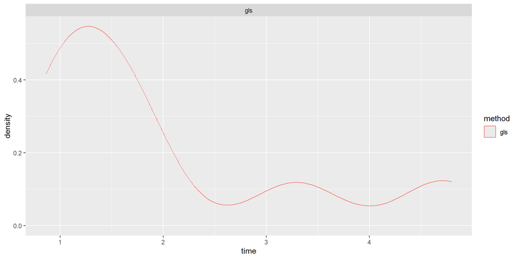

```r
ggplot() +
  geom_density(
    mapping = aes(
      x = time,
      col = method
    ),
    data = estimated.parameters
  ) +
  facet_wrap(
    facets = ~ method,
    scales = "free_y"
  )
```

# Visualise Estimated Parameters

```r
estimated.parameters <- parameters %>%
  expand_grid(
    run = seq(100)
  ) %>%
  reframe(
    generate.data(
      n.participants = n.participants,
      n.measurements = n.measurements,
      logit.ratio.1 = logit.ratio.1,
      logit.ratio.2 = logit.ratio.2,
      logit.ratio.3 = logit.ratio.3
    ) %>%
      estimate.model.and.get.coefficients.gls() %>%
      as_tibble_row(),
    .by = c(parameter.set, run)
  )
estimated.parameters
```

| parameter.set | run | logit.ratio.1 | logit.ratio.2 | logit.ratio.3 | time |
| --- | --- | --- | --- | --- | --- |
| 1 | 1 | -3.267124634 | 2.2885058 | -1.847435018 | 1.15 |
| 1 | 2 | -2.463994259 | 1.9289056 | -1.057262161 | 0.84 |
| 1 | 3 | -3.154344089 | 2.0889722 | -0.957835015 | 1.02 |
| 1 | 4 | -3.947675486 | 2.3434916 | -1.382647509 | 1.39 |
| 1 | 5 | -3.784452898 | 2.2445672 | -1.507836562 | 1.30 |
| 1 | 6 | -3.671421735 | 2.2220549 | -1.193408098 | 1.30 |
| 1 | 7 | -2.050535486 | 1.4012590 | 0.416934486 | 1.36 |
| 1 | 8 | -4.326399470 | 2.3775805 | -1.389954600 | 1.86 |
| 1 | 9 | -3.723749262 | 2.0882086 | -1.084820761 | 1.19 |
| 1 | 10 | -2.958602235 | 2.0954870 | -1.304271704 | 1.03 |

[output cut: 390 more lines]

We now visualise the distribution of the estimated parameters, for each set of the input parameters. We can add a vertical line to indicate the value of the original, input parameter.

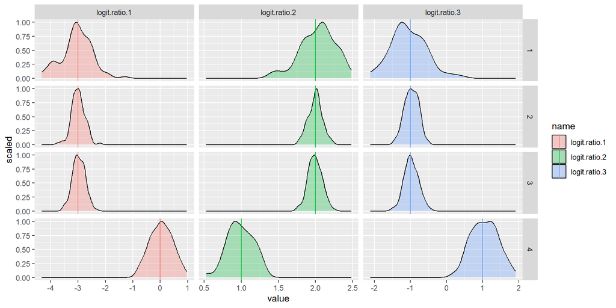

```r
ggplot() +
  geom_density(
    mapping = aes(
      x = value,
      y = after_stat(scaled),
      fill = name
    ),
    data = estimated.parameters %>%
      pivot_longer(
        cols = matches("log.")
      ),
    alpha = 0.3
  ) +
  geom_vline(
    mapping = aes(
      xintercept = value,
      col = name
    ),
    data = parameters %>%
      pivot_longer(
        cols = matches("log.")
      )
  ) +
  facet_grid(
    cols = vars(name),
    rows = vars(parameter.set),
    scales = "free"
  )
```

# Visualise Parameter Correlations

The estimated parameters may also correlate with each other. This is first visualised by listing the Pearson correlation in a matrix.

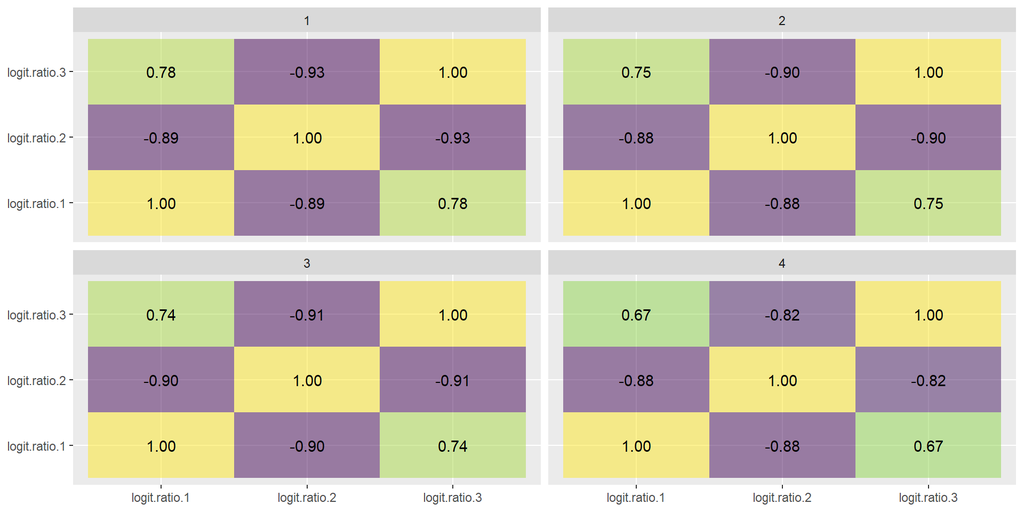

```r
ggplot(
  mapping = aes(
    x = parameter.1,
    y = parameter.2,
    fill = correlation,
    label = sprintf("%.2f", correlation)
  ),
  data = estimated.parameters %>%
    group_by(parameter.set) %>%
    reframe(
      expand_grid(
        parameter.1 = c("logit.ratio.1", "logit.ratio.2", "logit.ratio.3"),
        parameter.2 = c("logit.ratio.1", "logit.ratio.2", "logit.ratio.3")
      ),
      correlation = c(cor(data.frame(logit.ratio.1, logit.ratio.2, logit.ratio.3)))
    )
) +
  geom_tile(alpha = 0.5) +
  geom_text() +
  scale_fill_viridis_c() +
  guides(fill = "none") +
  labs(
    x = NULL,
    y = NULL
  ) +
  facet_wrap(
    facets = vars(parameter.set)
  )
```